# An analysis of activity data

## Loading and pre-processing

Downloading the dataset and import in to the R environment:

```r
temp <- tempfile()
download.file("https://d396qusza40orc.cloudfront.net/repdata%2Fdata%2Factivity.zip",temp)
df <- read.csv(unz(temp, "activity.csv"), sep = ",", stringsAsFactors = FALSE)
unlink(temp)
```

By looking at a summary of the data we can see that there are three variables in the dataframe: steps, date, and interval; with the steps column holding a noticeable amount of NA values.

```r
summary(df)
```

```
##      steps            date              interval
##  Min.   :  0.00   Length:17568       Min.   :   0.0
##  1st Qu.:  0.00   Class :character   1st Qu.: 588.8
##  Median :  0.00   Mode  :character   Median :1177.5
##  Mean   : 37.38                      Mean   :1177.5
##  3rd Qu.: 12.00                      3rd Qu.:1766.2
##  Max.   :806.00                      Max.   :2355.0
##  NA's   :2304
```

## Mean total number of steps taken per day

Assigning the total number of steps taken each day to a separate data frame using the dplyr package.

```r
library(dplyr)

as.Date(df$date) -> df$date_reformat

df %>%
  select(date_reformat, steps) %>%
  group_by(date_reformat) %>%
  summarise(Total = sum(steps)) %>%
  arrange(date_reformat, Total) -> df_totals
```

Using this summarised dataframe, we can now plot a histogram of the total steps taken per day.

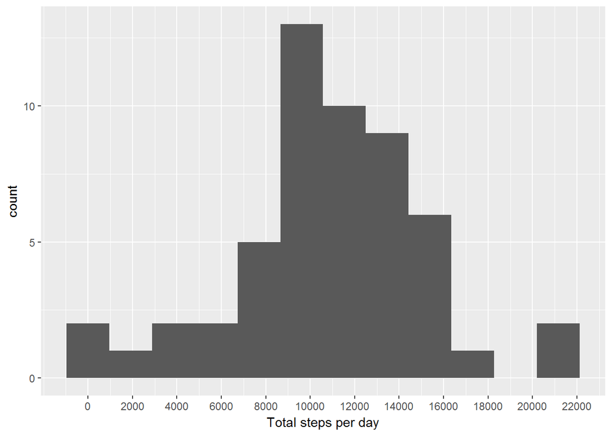

```r
library(ggplot2)

ggplot(df_totals, aes(Total)) +
  geom_histogram(bins = 12) +
  labs(x = "Total steps per day") +
  scale_x_continuous(breaks = pretty(df_totals$Total, 10))
```

Judging from the histogram, it appears that most of the totals steps fall in the range of 10000 to 14000 steps per day.

By summarising the data again, we can calculate the means and medians per day.

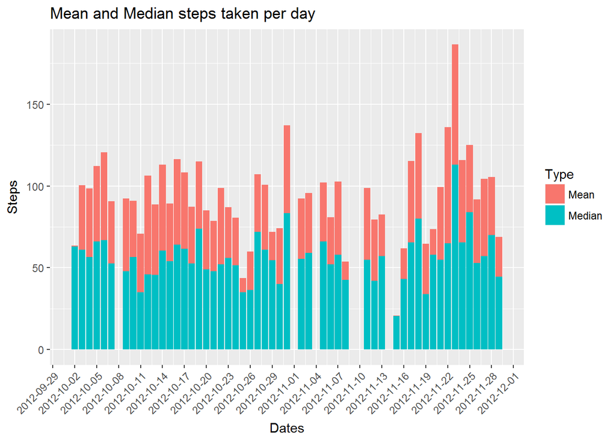

```r
df %>%
  select(date_reformat, steps) %>%
  group_by(date_reformat) %>%
  summarise(Avg = mean(steps, na.rm = TRUE), Type = "Mean") %>%
  arrange(date_reformat, Avg) -> df_means

df %>%
  select(date_reformat, steps) %>%
  filter(steps != 0) %>%
  group_by(date_reformat) %>%
  summarise(Avg = median(steps, na.rm = TRUE), Type = "Median") %>%
  arrange(date_reformat, Avg) -> df_medians

  rbind(df_means, df_medians) -> df_averages

ggplot(df_averages, aes(date_reformat, Avg, fill = Type)) +
  geom_bar(stat = "identity") +
  labs(x = "Dates", y = "Steps", title = "Mean and Median steps taken per day") +
  scale_x_date(date_breaks = "3 days") + theme(axis.text.x=element_text(angle=45, hjust=1))
```

There were plenty of zero steps that were taken, which distorts the median steps taken per day. These zero values had to be removed in order to show a meaningful median value. As shown in the graph, there is a clear noticeable disparity betweem the mean and median steps taken per day, which might imply that in some of the 5 minute intervals, the steps taken show extreme values.

## Average daily acivity pattern

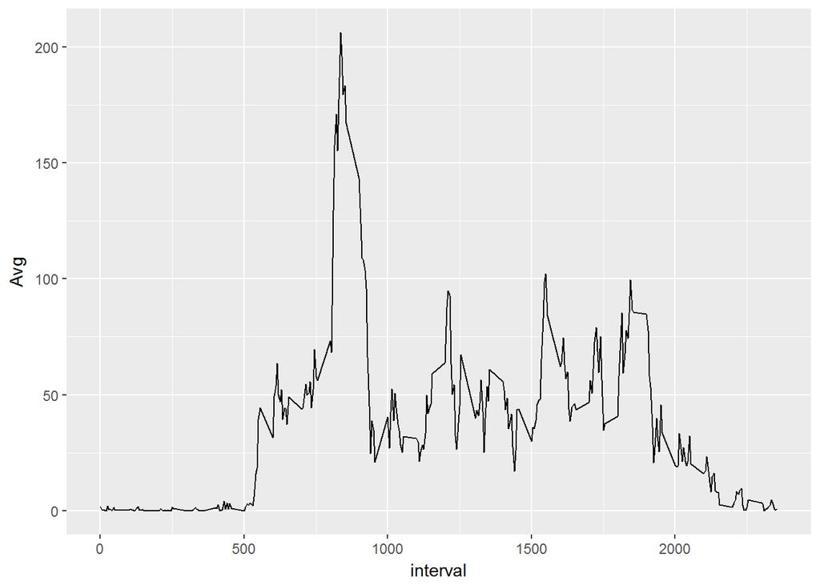

```r
 df %>%
 select(interval, steps) %>%
 group_by(interval) %>% summarise(Avg = mean(steps, na.rm = TRUE)) %>%
 arrange(interval, Avg) %>%

  ggplot(aes(interval, Avg)) + geom_line()
```

It would appear that, on average, the 835th interval shows the highest number of steps taken. This can also be easily seen by arranging the summarised dataframe in descending order of the mean steps per 5 minute interval, and printing out the top few rows.

```r
 df %>%
 select(interval, steps) %>%
 group_by(interval) %>% summarise(Avg = mean(steps, na.rm = TRUE)) %>%
 arrange(-Avg, interval) %>% head()
```

```
## # A tibble: 6 × 2
##   interval      Avg
##      <int>    <dbl>
## 1      835 206.1698
## 2      840 195.9245
## 3      850 183.3962
## 4      845 179.5660
## 5      830 177.3019
## 6      820 171.1509
```

## Imputing missing values

By looking at the summary of the data, we can see that there are 2304 rows of data with NA values. All these values are in the steps variable.

```r
summary(df)
```

```
##      steps            date              interval      date_reformat
##  Min.   :  0.00   Length:17568       Min.   :   0.0   Min.   :2012-10-01
##  1st Qu.:  0.00   Class :character   1st Qu.: 588.8   1st Qu.:2012-10-16
##  Median :  0.00   Mode  :character   Median :1177.5   Median :2012-10-31
##  Mean   : 37.38                      Mean   :1177.5   Mean   :2012-10-31
##  3rd Qu.: 12.00                      3rd Qu.:1766.2   3rd Qu.:2012-11-15
##  Max.   :806.00                      Max.   :2355.0   Max.   :2012-11-30
##  NA's   :2304
```

The number of rows that house NA values can also be checked by removing all the NA rows from the data frame and then substracting the total number of rows of this new dataframe from the totalrows in the original raw data.

```r
nrow(df) - nrow(na.omit(df))
```

```
## [1] 2304
```

Filling all the NA values in the steps variable using the average of the corresponding interval.

```r
df %>%
  select(interval, steps) %>%
  group_by(interval) %>%
  summarise(Avg = mean(steps, na.rm = TRUE)) -> int_avgs

df[is.na(df$steps), ] -> NA_df

merge(NA_df, int_avgs, by = "interval")$Avg -> NA_df$steps

rbind(NA_df, na.omit(df)) -> final_df
```

Now comparing the summary of the original datarame against the new dataframe

```r
summary(df)
```

```
##      steps            date              interval      date_reformat
##  Min.   :  0.00   Length:17568       Min.   :   0.0   Min.   :2012-10-01
##  1st Qu.:  0.00   Class :character   1st Qu.: 588.8   1st Qu.:2012-10-16
##  Median :  0.00   Mode  :character   Median :1177.5   Median :2012-10-31
##  Mean   : 37.38                      Mean   :1177.5   Mean   :2012-10-31
##  3rd Qu.: 12.00                      3rd Qu.:1766.2   3rd Qu.:2012-11-15
##  Max.   :806.00                      Max.   :2355.0   Max.   :2012-11-30
##  NA's   :2304
```

```r
summary(final_df)
```

```
##      steps            date              interval      date_reformat
##  Min.   :  0.00   Length:17568       Min.   :   0.0   Min.   :2012-10-01
##  1st Qu.:  0.00   Class :character   1st Qu.: 588.8   1st Qu.:2012-10-16
##  Median :  0.00   Mode  :character   Median :1177.5   Median :2012-10-31
##  Mean   : 37.38                      Mean   :1177.5   Mean   :2012-10-31
##  3rd Qu.: 27.00                      3rd Qu.:1766.2   3rd Qu.:2012-11-15
##  Max.   :806.00                      Max.   :2355.0   Max.   :2012-11-30
```

The new data frame final_df now has all the information of the original dataframe, except with the NA values filled in.

Comparing the previous histogram of total steps taken, to the total steps from the new dataframe.

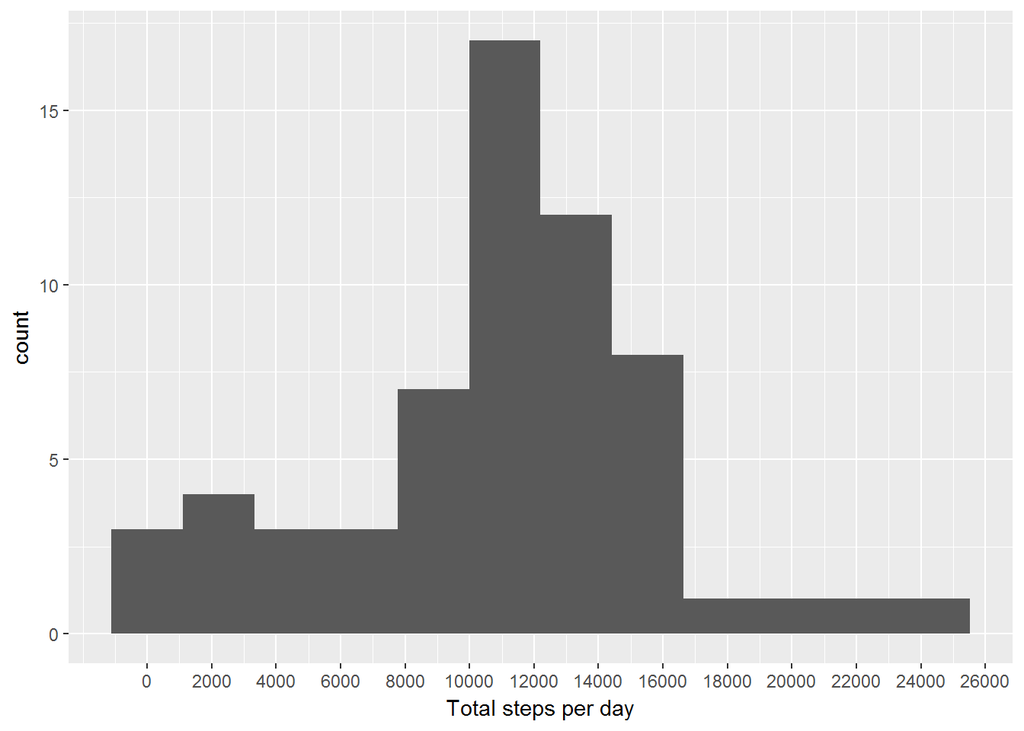

```r
final_df %>%
  select(date_reformat, steps) %>%
  group_by(date_reformat) %>%
  summarise(Total = sum(steps)) %>%
  arrange(date_reformat, Total) -> df_totals

ggplot(df_totals, aes(Total)) +
  geom_histogram(bins = 12) +
  labs(x = "Total steps per day") +
  scale_x_continuous(breaks = pretty(df_totals$Total, 10))
```

Recalculating means and medians per day

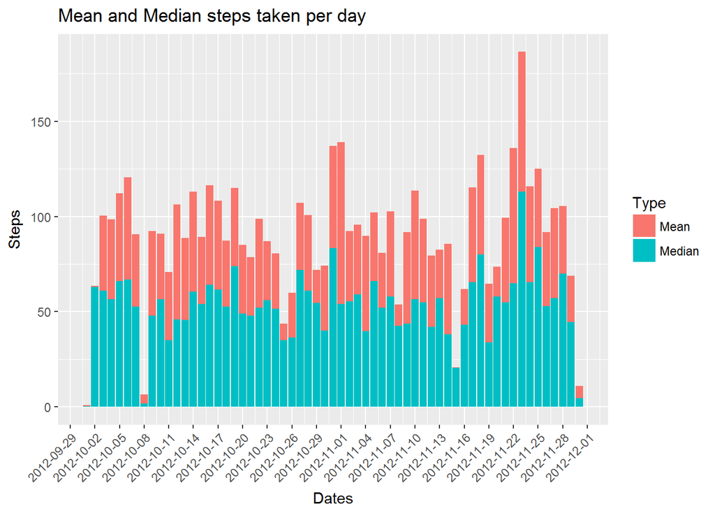

```r
final_df %>%
  select(date_reformat, steps) %>%
  group_by(date_reformat) %>%
  summarise(Avg = mean(steps, na.rm = TRUE), Type = "Mean") %>%
  arrange(date_reformat, Avg) -> df_means

final_df %>%
  select(date_reformat, steps) %>%
  filter(steps != 0) %>%
  group_by(date_reformat) %>%
  summarise(Avg = median(steps, na.rm = TRUE), Type = "Median") %>%
  arrange(date_reformat, Avg) -> df_medians

  rbind(df_means, df_medians) -> df_averages

ggplot(df_averages, aes(date_reformat, Avg, fill = Type)) +
  geom_bar(stat = "identity") +
  labs(x = "Dates", y = "Steps", title = "Mean and Median steps taken per day") +
  scale_x_date(date_breaks = "3 days") + theme(axis.text.x=element_text(angle=45, hjust=1))
```

```r
final_df %>%
  select(date_reformat, steps) %>%
  group_by(date_reformat) %>%
  summarise(Avg = mean(steps, na.rm = TRUE), Type = "Mean") %>%
  arrange(date_reformat, Avg) -> df_means_final

final_df %>%
  select(date_reformat, steps) %>%
  filter(steps != 0) %>%
  group_by(date_reformat) %>%
  summarise(Avg = median(steps, na.rm = TRUE), Type = "Median") %>%
  arrange(date_reformat, Avg) -> df_medians_final

  rbind(df_means_final, df_medians_final) -> df_averages_final

  merge(df_averages, df_averages_final, by=c("date_reformat", "Type")) %>%
  mutate(diff = Avg.x - Avg.y) %>% summary()
```

```
##  date_reformat            Type               Avg.x
##  Min.   :2012-10-01   Length:122         Min.   :  0.1424
##  1st Qu.:2012-10-16   Class :character   1st Qu.: 35.4627
##  Median :2012-10-31   Mode  :character   Median : 46.4340
##  Mean   :2012-10-31                      Mean   : 45.2197
##  3rd Qu.:2012-11-15                      3rd Qu.: 56.4764
##  Max.   :2012-11-30                      Max.   :113.0000
##      Avg.y               diff
##  Min.   :  0.1424   Min.   :0
##  1st Qu.: 35.4627   1st Qu.:0
##  Median : 46.4340   Median :0
##  Mean   : 45.2197   Mean   :0
##  3rd Qu.: 56.4764   3rd Qu.:0
##  Max.   :113.0000   Max.   :0
```

# Differences in activity between weekends and weedays

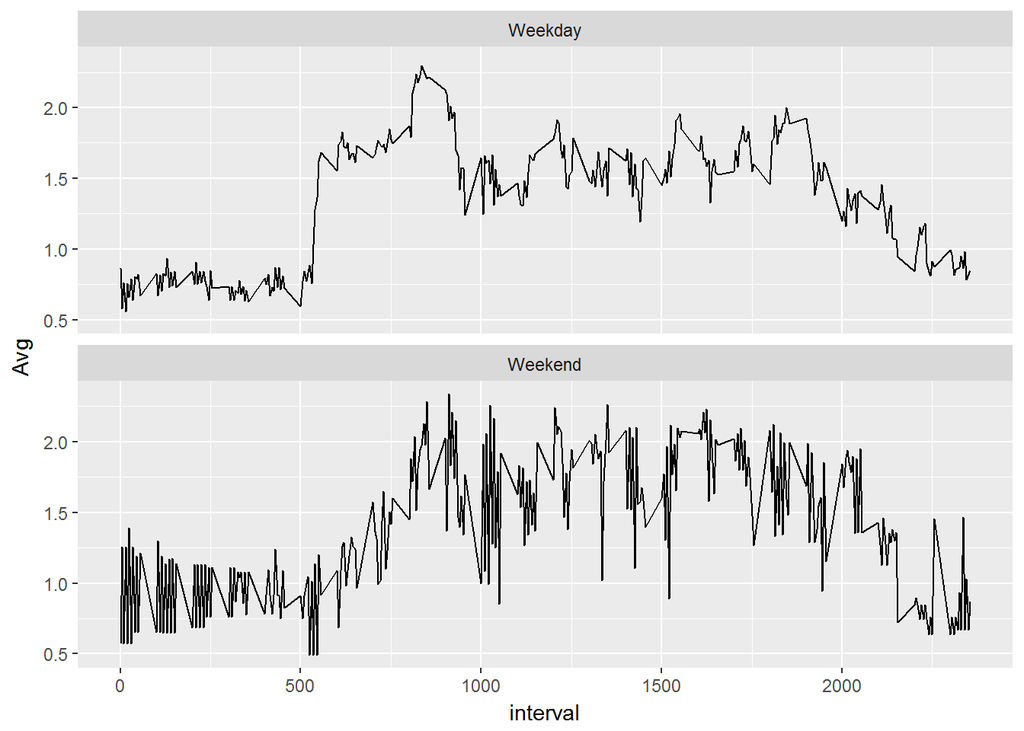

```r
final_df$date_reformat %>% weekdays() -> days

days == c("Saturday", "Sunday") -> weekend_log

final_df$Day <- NA

final_df$Day[weekend_log] <- "Weekend"
final_df$Day[!weekend_log] <- "Weekday"

as.factor(final_df$Day) -> final_df$Day


final_df %>%
  select(interval, steps, Day) %>%
  group_by(interval, Day) %>%
  summarise(Avg = log10(mean(steps))) %>%
  arrange(interval, Avg) %>%

  ggplot(aes(interval, Avg)) + geom_line() +
  facet_wrap(~Day, nrow = 2, ncol = 1)
```